# Star Rating Assigner Based On User Reviews

## Problem Statement:

We are provided with data set that contains reviews about a business and the ratings provided by users. Having this data as the input data for our model, we need to build a model whichwill assignthe stars based on the review provided.

## Import Libraries

```python
import numpy as np
import pandas as pd
```

## Import Dataset

The Dataset available as .csv file, use pandas library read_csv() to import data

```python
yelp= pd.read_csv('yelp.csv')
```

```python
yelp.head()
```

|  | business_id | date | review_id | stars | text | type | user_id | cool | useful | funny |
| --- | --- | --- | --- | --- | --- | --- | --- | --- | --- | --- |
| 0 | 9yKzy9PApeiPPOUJEtnvkg | 2011-01-26 | fWKvX83p0-ka4JS3dc6E5A | 5 | My wife took me here on my birthday for breakf... | review | rLtl8ZkDX5vH5nAx9C3q5Q | 2 | 5 | 0 |
| 1 | ZRJwVLyzEJq1VAihDhYiow | 2011-07-27 | IjZ33sJrzXqU-0X6U8NwyA | 5 | I have no idea why some people give bad review... | review | 0a2KyEL0d3Yb1V6aivbIuQ | 0 | 0 | 0 |
| 2 | 6oRAC4uyJCsJl1X0WZpVSA | 2012-06-14 | IESLBzqUCLdSzSqm0eCSxQ | 4 | love the gyro plate. Rice is so good and I als... | review | 0hT2KtfLiobPvh6cDC8JQg | 0 | 1 | 0 |
| 3 | _1QQZuf4zZOyFCvXc0o6Vg | 2010-05-27 | G-WvGaISbqqaMHlNnByodA | 5 | Rosie, Dakota, and I LOVE Chaparral Dog Park!!... | review | uZetl9T0NcROGOyFfughhg | 1 | 2 | 0 |
| 4 | 6ozycU1RpktNG2-1BroVtw | 2012-01-05 | 1uJFq2r5QfJG_6ExMRCaGw | 5 | General Manager Scott Petello is a good egg!!!... | review | vYmM4KTsC8ZfQBg-j5MWkw | 0 | 0 | 0 |

## EDA and Visualization

```python
yelp.describe()
```

|  | stars | cool | useful | funny |
| --- | --- | --- | --- | --- |
| count | 10000.000000 | 10000.000000 | 10000.000000 | 10000.000000 |
| mean | 3.777500 | 0.876800 | 1.409300 | 0.701300 |
| std | 1.214636 | 2.067861 | 2.336647 | 1.907942 |
| min | 1.000000 | 0.000000 | 0.000000 | 0.000000 |
| 25% | 3.000000 | 0.000000 | 0.000000 | 0.000000 |
| 50% | 4.000000 | 0.000000 | 1.000000 | 0.000000 |
| 75% | 5.000000 | 1.000000 | 2.000000 | 1.000000 |
| max | 5.000000 | 77.000000 | 76.000000 | 57.000000 |

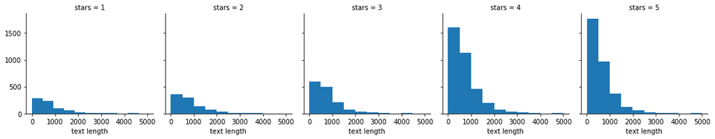

```python
import matplotlib.pyplot as plt
import seaborn as sns
%matplotlib inline

# Use facetgrid of seaborn library to create grid of 5 histogram of text length of the text based on the star ratings

yelp['text length'] = yelp['text'].apply(len)

plot= sns.FacetGrid(yelp, col='stars')
plot.map(plt.hist,'text length')
```

#### Create a count plot of number of occurance for each type of star ratings

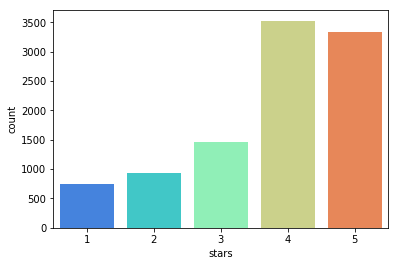

```python
sns.countplot(x='stars', data=yelp, palette='rainbow')
```

```python
yelp.corr()
```

|  | stars | cool | useful | funny | text length |
| --- | --- | --- | --- | --- | --- |
| stars | 1.000000 | 0.052555 | -0.023479 | -0.061306 | -0.114674 |
| cool | 0.052555 | 1.000000 | 0.887102 | 0.764342 | 0.241451 |
| useful | -0.023479 | 0.887102 | 1.000000 | 0.723406 | 0.293975 |
| funny | -0.061306 | 0.764342 | 0.723406 | 1.000000 | 0.251760 |
| text length | -0.114674 | 0.241451 | 0.293975 | 0.251760 | 1.000000 |

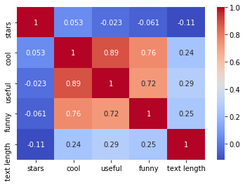

```python
sns.heatmap(yelp.corr(),annot=True, cmap='coolwarm')
```

## Data preprocessing

#### Let us filter 1 & 5 stars alone and use the data to build a model.

Create a dataframe called yelp_class that contains the columns of yelp dataframe but for only the 1 or 5 star reviews.

```python
yelp_class= yelp[(yelp.stars==1) | (yelp.stars==5)]
```

#### Lets create two objects X and y.

X is the text column of yelp_class (Input).

y is the star column of yelp_class( Label to be predicted).

```python
X= yelp_class['text']
y= yelp_class['stars']
```

### Import CountVectorizer and create a countvectorizer object

```python
from sklearn.feature_extraction.text import CountVectorizer
cv=CountVectorizer()
X=cv.fit_transform(X)
X
```

```
<4086x19183 sparse matrix of type '<class 'numpy.int64'>'
	with 317288 stored elements in Compressed Sparse Row format>
```

## Train and Test Data Split

Split Train and Test Data

```python
from sklearn.model_selection import train_test_split
X_train,X_test,y_train,y_test= train_test_split(X,y,test_size=0.25, random_state=101)
```

## Build the Model

import MultinominalNB, create an instance and fit the train data

```python
from sklearn.naive_bayes import MultinomialNB
nb = MultinomialNB()
nb.fit(X_train, y_train)
```

```
MultinomialNB(alpha=1.0, class_prior=None, fit_prior=True)
```

## Prediction and Evaluations

Use predict method of NB to predict labels from X_test

```python
predictions= nb.predict(X_test)
```

#### Create Confusion matrix and Classification_Report using these predicton and y_test

```python
from sklearn.metrics import confusion_matrix, classification_report
print (classification_report(y_test, predictions))
```

```
              precision    recall  f1-score   support

           1       0.86      0.74      0.80       184
           5       0.95      0.97      0.96       838

   micro avg       0.93      0.93      0.93      1022
   macro avg       0.90      0.86      0.88      1022
weighted avg       0.93      0.93      0.93      1022
```

```python
print (confusion_matrix(y_test,predictions))
```

```
[[137  47]
 [ 22 816]]
```

#### The model buils seems to classify the reviews to 5 and 1 star correctly with accuracy of 93%